# This Is How We Do It

Journal of Management Inquiry 2016, Vol. 25(3) 301–321 © The Author(s) 2015 Reprints and permissions: sagepub.com/journalsPermissions.nav DOI: 10.1177/1056492615612577 jmi.sagepub.com

*Non-Traditional Research*

Work roles involving “necessary evils” require employees to psychologically or physically harm other human beings to produce a perceived “greater good” (Molinsky & Margolis, 2005). Examples of necessary evils abound across many kinds of work contexts, from doctors who must implement a painful procedure to cure a patient, to policemen and policewomen who must deliver news of an accident or death to a victim’s loved one, to therapists who purposefully expose patients to their greatest fears (e.g., spiders, chemicals, vomit) to treat the patient’s anxiety disorder. Such work is often associated with vulnerability to stress and burnout for the worker because it involves ongoing, intensive interactions with others and requires demanding emotional labor (cf. Farber, 1983; Foureur, Besley, Burton, Yu, & Crisp, 2013; Slocum-Gori, Hemsworth, Chan, Carson, & Kazanjian, 2013). Further, negative emotions, such as guilt and anxiety, are associated with necessary evils tasks because one is—at least in part—responsible for the witnessed pain and suffering of others (Margolis & Molinsky, 2008). The costs of these experiences are not inconsequential. Beyond the negative impacts on the worker (Farber, 1983), it is evident that individuals who carry out necessary evils play a direct, critical role in influencing the well-being of others through their work. If they suffer great distress, they are likely to be less able to address the needs and concerns of those harmed, and less capable of producing the desired greater good.

Conversely, research demonstrates that perceived prosocial impact, which is the experience that one has helped another (Grant & Sonnentag, 2010), is positively related to individuals’ well-being (e.g., Cohen & Hoberman, 1983; Cohen & McKay, 1984; Cohen & Wills, 1985). Whereas stressful life events deplete social, psychological, and physical resources in humans, according to a resource-based view on stress, positive events replenish these resources (Cohen & Hoberman, 1983; Folkman & Moskowitz, 2000; Hobfoll, 1989, 1991), and thereby serve as an important coping mechanism. Research demonstrates that choosing to help others, for instance, through activities such as volunteerism or acts of kindness can generate positive experiences and events which offset the potential personal harms associated with negative experiences and events (Moskowitz, 2010). Prior work has also examined employees’ helping and harming others through necessary evils tasks and the consequences for the employee harmed (Margolis & Molinsky, 2008) or

1Boston College, Chestnut Hill, MA, USA 2Northeastern University, Boston, MA, USA 3University of Victoria, British Columbia, Canada

**Corresponding Author:** Judith A. Clair, Associate Professor, Boston College, Chestnut Hill, MA 02467, USA. Email: clairju@bc.edu

**This Is How We Do It: How Perceived Prosocial Impact Offsets Negative Personal Outcomes Associated With Carrying Out Necessary Evils**

#### **Judith A. Clair<sup>1</sup>, Jamie J. Ladge<sup>2</sup>, and Rick Cotton<sup>3</sup>**

**Abstract** “Necessary evils” require employees to psychologically or physically harm others to produce a perceived greater good. Employees can also help others during necessary evils tasks by providing assistance and support to those harmed. Through an inductive, qualitative study of human resources employees’ experiences carrying out downsizing, we explore how the perception of helping the person one has harmed relates to the harm-doer’s ability to withstand the challenges of having to carry out necessary evils. Our research culminates in a theoretical model showing that (a) seven kinds of stressors were associated with participants’ involvement in necessary evils tasks, (b) these stressors triggered a series of negative personal outcomes (negative self-focused emotions, emotional exhaustion, and intention to turnover), and (c) perceived prosocial impacts ameliorated these negative personal outcomes. We discuss the implications our findings for research and practice, address limitations of our study, and offer ideas for future research.

**Keywords** downsizing/layoffs/restructuring, affect/emotions, qualitative research

more broadly how employees’ care and compassion when others hurt has the power to be a generative force in organization (cf. Dutton & Workman, 2011). Although there is some evidence that helping a variety of others can offset the perception that one has harmed a variety of others at work (Grant & Campbell, 2007), prior research has not deeply examined how experiences of helping and harming others via necessary evils tasks relate to the harm-doer’s well-being (Dutton, Workman, & Hardin, 2014). Scholars recognize that this is an important and ripe area for future research (Margolis & Molinsky, 2008). To respond to a need for further research, we explore the following research question: How does the perception of helping the person one has harmed in the context of necessary evils work tasks relate to the harm-doer’s ability to withstand the challenges of having to carry out these difficult work roles?

Specifically, we conducted an inductive, qualitative study in which we sought to build theory within a specific empirical context—that of human resources (HR) employees who must repeatedly participate in carrying out downsizing events. Downsizing is a widely used managerial tool that has been implemented globally for more than two decades and is a primary strategy for a large number of companies and governmental agencies looking to cut costs and improve profitability (McKinley, Mone, & Barker, 1998; Mirabal & DeYoung, 2005). We adopt the definition of downsizing as “a constellation of stressor events centering around pressures toward work force reductions which place demands upon the organization, work groups, and individual employees, and require a process of coping and adaptation” (Shaw & Barrett- Power, 1997, p. 109). During downsizing events, HR employees carry out necessary evils tasks by assisting in making decisions about whom to fire, supporting the process of carrying out the downsizing, and playing a major role in the termination discussions with those who’ve been targeted to be let go. While HR employees must harm others during a downsizing, they also can and do assist others in need in light of the difficult circumstances. HR employees are frequently involved in downsizing events because these events have become part of the landscape of organizational change initiatives and the tasks of carrying out downsizing often fall within the domain of the HR department. Therefore, HR employees find that they harm and help others again and again in the context of downsizing events. Our study was designed to shed light on the stressors associated with carrying out downsizing, and how HR employees cope with these stressors. We found that perceived helping and harming played a critical role; and therefore, we focused our analysis to explore these relationships.

The results of our study, which culminated in a theoretical model, make several specific contributions. First, Margolis and Molinsky (2008) proclaimed that more work must be done to deeply examine the experience of individuals who must carry out necessary evils tasks. We do so by opening the

“black box” linking employees’ perceptions of harming and helping others in downsizing initiatives and the employee’s ability to withstand the challenges of their emotionally charged work. In light of our empirical context focusing on the work of HR employees, we seek to make an additional scholarly contribution by heeding researchers’ call for scholars to build knowledge on the functioning and impacts of HR systems at the level of the individual HR employee (Mossholder, Richardson, & Settoon, 2011). We additionally build beyond prior work by offering deep empirical insights concerning HR practices which often involve necessary evils (Margolis, Grant, & Molinsky, 2007). Finally, our results seek to add understanding to limited research about the experiences of employees who must carry out necessary evils as part of downsizing initiatives (e.g., Clair & Dufresne, 2004; Gandolfi, 2009).

#### **Necessary Evils Work Roles**

Our study builds upon relatively recent research focused on work tasks involving “necessary evils.” Necessary evils are defined as follows: “Tasks in which a person must knowingly and intentionally cause emotional or physical harm to another human being in the service of achieving some perceived greater good or purpose” (Margolis & Molinsky, 2008, p. 847). Research demonstrates that such work can be emotionally draining and difficult to carry out because the worker must not only repeatedly witness pain and suffering when harm is delivered to others, the worker must also bear responsibility for instigating the pain and suffering witnessed (Margolis & Molinsky, 2008; Molinsky & Margolis, 2005). As with work roles where one is exposed to others’ traumatization (e.g., emergency workers, firefighters), workers who carry out necessary evils can be prone to negative psychological consequences, such as discomfort, self-doubt, helplessness, anxiety, fear, sadness, and worry (cf. Bartlett & Riches, 2007; Lutfey & Maynard, 1998; Margolis & Molinsky, 2008; Moldovan, 2009; Rassin, Levy, Schwartz, & Silner, 2006; Tucker et al., 2002). Burnout and even secondary post-traumatic distress are also well-documented outcomes of work involving exposures to others’ pain and suffering (Figley, 1995; McCann & Pearlman, 1990; Tucker et al., 2002).

Scholars express interest in understanding how workers cope with the stressors associated with their necessary evils tasks. Research demonstrates how individuals often cope by withdrawing as a way of protecting the self from the emotional tolls of the work. For instance, Cameron and Payne (2011) demonstrated that a collapse in the compassion expressed toward large groups of victims is triggered by peoples’ need to protect the self from overwhelming emotions. Similarly, Clair and Dufresne (2004) found that individuals who laid off employees in a downsizing coped by emotionally withdrawing (e.g., “going numb”), cognitively withdrawing (e.g.,

reframing the work as routine), and physically removing themselves from the intense emotions of those being laid off (e.g., hiding in one’s office). Other researchers (Gandolfi, 2009; Margolis & Molinsky, 2008) also found support that those who perform necessary evils often withdraw the self emotionally, cognitively, or behaviorally from difficult interactions involving harm to others.

In contrast to a withdrawal coping, perceived prosocial impact, or the experience of having provided help to others, can be considered a form of engagement-coping in which one focuses on one’s capacity to reach out to and help the person who has been harmed, for instance by providing support and assistance. Giving help and assistance to others can often be a part of one’s work role in which necessary evils are carried out. For instance, HR employees who carry out downsizing do not just lay off employees; they also are often involved in helping employees understand their termination packages or even in securing those terminated re-employment options. However, perceived prosocial impact may also entail extra-role behaviors such as expressing empathy and advocating on the harmed person’s behalf. As stated in Margolis and Molinsky (2008), a ripe area for research is to explore the relationship between the harm-doer’s more engaged approach to necessary evils roles and the harmdoer’s well-being.

#### **A Resource-Based View of Stress and the Buffering Hypothesis**

Our work builds upon the buffering hypothesis, which proposes that negative events and experiences draw down social, emotional, and physical resources of the person whereas positive events and experiences provide such resources, and thereby act as a buffer by replenishing depleted resources. For example, Midlarsky (1991) proposed that helping others may provide a benefit because it distracts the actor from personal troubles, enhances one’s life value, improves one’s self-esteem and mood, and increases perceived belongingness. Lilius (2012) proposed that “restorative” interactions with clients can buffer human service workers from burnout by providing positive affect, self-affirmation, and perceived prosocial impact which offsets cognitive emotional strain associated with intensive caregiving. Bono, Glomb, Shen, Kim, and Koch (2013) proposed that positive workplace events build psychological resources by fulfilling a person’s basic human needs, such as for belongingness and autonomy (Baumeister & Leary, 1995; Ryan & Deci, 2000), that can be depleted in the context of negative, stressful life events. In one of two studies, Grant and Sonnentag (2010) found that fundraisers who perceived that funds raised benefited others—by funding scholarships for underprivileged and out-of-state students or construction of new buildings for the community—experienced lower burnout symptoms. More to the focus of our research on necessary evils, Grant and Campbell

(2007) found that helping others in a variety of ways (e.g., providing assistance to a supervisor) assuaged the negative impacts of harming others in a variety of ways (e.g., enforcing rules, turning down a request). Based in moral identity and cognitive dissonance theories, they proposed that believing that one is helping others allows the person to justify acting in ways that harm others. Although instructive, this research is unable to provide insight into what is going on inside of the “black box” linking perceived help-giving to the person one has harmed and the harm-doer’s well-being, which is the motivation for our study.

#### **Method**

This research sought to gain insights into the experiences of employees who must carry out necessary evils within the context of the HR employee who deploys downsizing initiatives. Qualitative research is best implemented when researching the real experiences, behavior, emotions, and feelings of an individual (Strauss & Corbin, 1990). Our approach follows an interview-based technique in which we sought to analyze and determine common themes across multiple participants in our study within a particular context. This is a method encouraged by Miles and Huberman (1994), where the research goal is to “capture data on the perceptions of local actors from the inside through the process of deep attentiveness, of empathic understanding, and of suspending or bracketing preconceptions about the topics under discussion” (Strauss & Corbin, 1990, p. 6). Our aim was to build new theoretical insights while also drawing from existing, related literature. Through our interviews, we viewed our participants more as “informants” (Bogdan & Biklen, 1998, p. 32) rather than simply “respondents” (Yin, 1994, p. 84). This approach enabled us to obtain varied meanings and interpretations of the experiences of our research participants so that we could generate new theoretical insights and provide a story that uncovered a more complete picture of the shared experiences of the HR downsizer.

#### *Participants*

To recruit participants for the role of HR downsizer, we used snowball sampling. Snowball sampling is often used for populations that are not easily identified or accessed and involves building a sample through referrals (O’Leary, 2004). First, we distributed a call for participants to alumni of an executive education program at a university in the Northeast United States. Second, we recruited participants through our own networks of professional contacts. And third, at the end of each interview, we also asked for referrals to additional participants. Our interviews were thus built through direct and indirect professional and personal connections resulting in participants drawn from companies in the Northeast United States, a region of the world that has experienced tens

of thousands of terminations over the last two decades (Bureau of Labor Statistics, 2013).

In total, this study includes 21 in-depth interviews with HR employees who experienced repeated downsizing roles, a number consistent with the case study literature which suggests that an acceptable number of interviewees for this kind of study would be from 20 to 50 participants (Larsson, 1993). Our sample included 2 HR generalists, 5 vice president–level HR professionals, 8 individuals who labeled their jobs as “director” or “senior manager” of HR, 3 HR internal consultants, and 3 individuals who labeled their positions as HR specialists. All but 1 participant, who had 6 years of experience in HR, had been in an HR position for 8 or more years. Seven of the 21 participants had more than 20 years of experience in HR. Whereas 2 participants had carried out a minimum of three major downsizing events, 15 of the 21 participants carried out five or more downsizing events over their careers. One participant had implemented more than 20 downsizing events. Participants’ estimates ranged from 20 to more than 250 individuals that they’d reported having personally laid off in downsizing events over their careers. Some individuals were involved in additional layoffs in which they did not personally deliver the message to the person being downsized. Fourteen of the 21 participants were women. Participants currently worked for large firms across a wide range of industries. All participants worked for different companies except for 2 sets of participants, who worked for the same two firms. All were responsible for carrying out a downsizing, and all but 2 participants were additionally involved in the decision making, planning the layoffs, and managing the aftermath. Refer to Table 1 for detail on participant and organization demographics.

#### *Interview Protocol*

Our interview protocol included semi-structured questions that prompted participants to reflect on their current and past downsizing experiences (see Appendix). The interview protocol covered both personal and work-related topics as well as specific questions concerning participants’ reactions to their downsizing-related work. There were four general categories of interview questions. The first category included a set of warm-up questions focused on participants’ current role within their organization. At this time, we also asked participants about the number of downsizing initiatives they’d participated in previously and roughly how many people they had personally laid off.

After the warm-up questions, we moved to the second section of our interview protocol, in which we asked participants to recount details of several previous experiences with downsizing. We started by asking participants to reflect on the details of their very first experience with downsizing. We then asked them to reflect on their most recent downsizing event, and asked them to compare and contrast their most

recent experiences with their first time. We probed to reveal what remained the same and what had changed in their intrapsychic experiences of and approaches to downsizing.

A third section of the interview protocol focused on delving more deeply into participants’ personal experiences with their role. We asked participants questions that prompted them to reflect on how they personally seek to approach their downsizing role, how they identify with the role, how they experience others’ reactions to their involvement in downsizing, and how they think their repeated experiences with downsizing impacts them personally. A final section of the interview protocol asked participants to reflect on their views about best and worst practices associated with carrying out downsizing. We also asked our participants to hypothetically offer advice to novices, and to organizations, about how to effectively carry out downsizing—what practices they thought should be used, and those to be avoided.

The interviews took between 45 to 90 min to conduct. We gave participants the option of being off the record whereby

**Table 1.** Demographic Information.

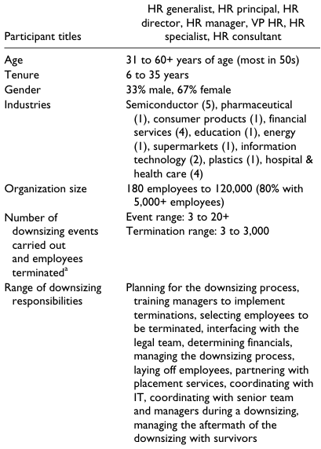

NOTE: complex table shown as an image of the PDF; the text below is a rough machine extraction and may be mis-aligned.

**extracted text (unreliable layout)**

*Note.* HR = human resources. aDoes not indicate number of people participants personally laid off in termination meetings.

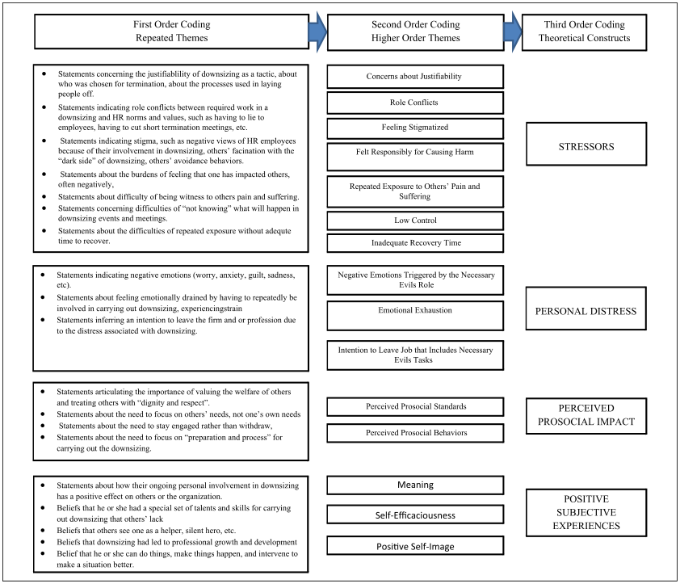

NOTE: figure/graphic rendered as an image from the PDF; its content is not machine-readable text. Caption (if any) follows as the next block.

we listened but did not capture, digitally or in our notes, exactly what they said. In addition, some interviewees, to protect confidentiality, sometimes did not want to be recorded saying others’ names and this allowed us to capture what they were saying without creating a digital record of them implicating other HR employees or identifying specific people whom they laid off. We also periodically stopped the interview for a few minutes if participants became emotional and/or wanted to collect themselves.

#### *Data Analysis*

To analyze our data, we followed the guidelines of qualitative research noted by Miles and Huberman (1994). Our analysis iterated between data, prior research, and our own

emergent theoretical ideas. This iterative process led us to build a model drawing from the collective stories of our participants and how they experienced their repeated downsizing work.

Our data analysis approach followed the three-step procedure which is now widely adopted by qualitative scholars (see Locke, 2001; Miles & Huberman, 1994; Pratt, Rockmann, & Kaufmann, 2006; Strauss & Corbin, 1990), which involves (a) creating provisional categories and firstorder codes, (b) integrating first-order codes and creating theoretical categories as second-order codes, and (c) delimiting theory by aggregating theoretical dimensions into thirdorder codes. In Figure 1, we summarize the coding process, which details the initial repeating themes, higher order conceptual subthemes, and theoretical constructs.

**Figure 1.** Three-step analysis process.

*Step 1: Creating provisional categories and first-order coding.* This first step involves identifying statements in one’s data that provide insight into informant’s views of the world to build first-order codes and provisional categories (Pratt et al., 2006). After completing our interviews, we entered all of our data into the Atlas ti 5.0 qualitative data management program (Muhr, 2004). We initially entered a preliminary set of code names into Atlas ti that we gleaned from prior research (Clair & Dufresne, 2004; Clair, Dufresne, Jackson, & Ladge, 2006). However, as we read through our data, we then quickly built beyond this initial set of codes through an open-coding approach (Locke, 2001), by which we assigned a preliminary label to statements in our data that appeared to share a common focus. For instance, we encountered statements in our data that had to do with participants’ feelings of efficaciousness in carrying out their downsizing tasks. As we found sets of common statements across the interviews, we started to move from the initial first-order code names that were descriptive in nature toward provisional categories. For example, our first-order code called “statements about how participants felt that they had mastered the skills necessary for carrying out their work” was assigned the provisional category “mastery.” Our goal at this time was to stay as closely grounded in our data as possible. Therefore, we assigned code names and assigned provisional categories, but sought not to move too quickly away from the data to our building theory stage. The first two authors met a number of times to review our emergent first-order codes and provisional categories. As a result of these meetings, we changed the codes and provisional categories several times as we moved through our data analysis after discussing emergent themes with one another.

*Step 2: Integrating first-order codes and creating theoretical categories.* The second step in data analysis involved consolidating first-order codes linked to provisional categories into groupings that represented a theoretical category. In this way, we moved from ideas that were grounded in our data toward more abstract theoretical constructs. To illustrate, two of the provisional categories that emerged from Step 1 in our data analysis were called “making a difference in others’ lives,” which included statements indicating the person’s beliefs that he or she has made a positive difference in others’ lives through his or her downsizing work, and “positive difference made in own life,” which included statements about how the person’s involvement in downsizing has had positive personal and professional benefits. These provisional categories were brought together under a shared theoretical category called “meaningfulness” because they each depicted positive consequential impacts that felt personally meaningful. At this stage, we also continued to consolidate data by abandoning provisional categories that did not contain enough data to warrant further inclusion. We also iterated between our data and the literature to generate a richer theoretical understanding of data. We continued to periodically meet in person to reflect on our data analysis process and to

make decisions about the story that was emerging from our data.

*Step 3: Delimiting theory by aggregating theoretical dimensions.* Pratt et al. (2006, p. 240) describe the final step as the point at which researchers look for dimensions underlying theoretical categories to understand how different categories fit together into a coherent picture. This is often a creative moment in the qualitative research process, in which the researcher must determine what story is being told by his or her data. The researcher does so by comparing and contrasting the theoretical categories that have emerged from the data analysis and “trying on” different potential theoretical frameworks that adequately represent the story. In starting this process, we noticed that participants in our study often discussed how their standards and approaches to downsizing others allowed them to bear the burdens associated with repeated downsizing. We found linkages in participants’ statements that depicted how the ideologies and practices of helping those impacted by the downsizing arose, and how these practices assuaged their sense of distress over the harm-causing work they repeatedly carried out. We went through several iterations of our emergent model, fine- turning it to ensure that it captured the core story. All disagreements between the two independent coders were resolved through discussion. We present our findings and model next.

#### **Findings**

Through our study of HR employees who must carry out downsizing events as part of their HR role, we built a theoretical model that sheds light on the “black box” linking experiences of harming, helping, and the well-being of the employee who must carry out necessary evils tasks (see Figure 2). Building directly from our empirical findings and linking to prior theory, our model proposes that employees experience a series of seven psychologically draining stressors within the context of their necessary evils tasks. These stressors are often associated with considerable negative personal outcomes, which included a set of general aversive, self-focused emotional reactions (e.g., anxiety, worry, discomfort), emotional exhaustion, and the expressed intention to turnover. However, the negative personal consequences experienced through necessary evils tasks appear to be at least somewhat mitigated when employees more strongly perceive having had prosocial impacts in the form of (a) adherence to prosocial standards and (b) enactment of prosocial behaviors oriented toward helping others who are harmed. We propose that the negative outcomes of their necessary evils role are offset by three kinds of positive subjective experiences evoked by the perception that one has had a positive impact: increased meaning, enhanced self-efficaciousness, and greater positive self-worth. We explain our model next.

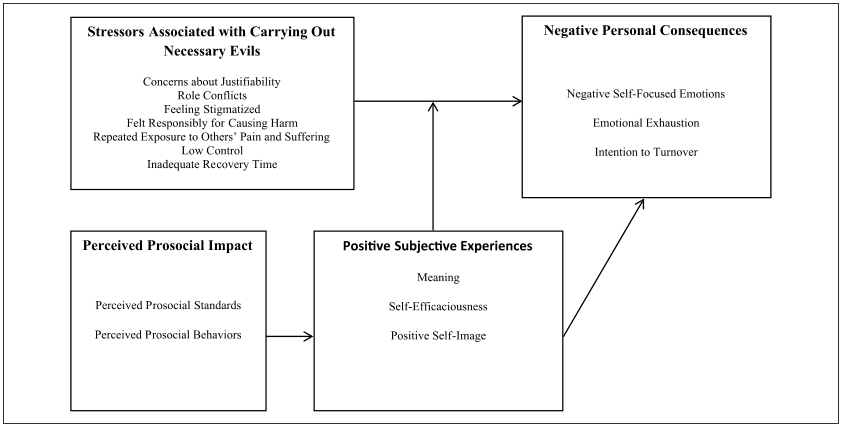

NOTE: figure/graphic rendered as an image from the PDF; its content is not machine-readable text. Caption (if any) follows as the next block.

#### *Stressors*

HR employees discussed seven types of stressors associated with having to carry out downsizing events: concerns about justifiability, conflicting role obligations, feeling stigmatized by others, felt responsibly for having negative life-altering impacts on others’ lives, repeated exposure to others’ pain and suffering, experiences of low control, and inadequate recovery time between events.

*Concerns about justifiability.* First, our data revealed that one stressor was a greater concern about the justifiability of downsizing processes and/or outcomes. The concerns about justifiability of downsizing were twofold. A first concern about the justifiability of downsizing related to whether downsizing as an organizational tactic to improve efficiencies or to achieve greater profitability actually achieved the positive objectives sought by their firms. Individuals expressed greater anxiety associated with their downsizing roles when they did not believe fully or at all in the organization’s use of this strategy, but nonetheless they were required to carry out downsizing as part of their required HR responsibilities (see Table 2 for illustrative quotes).

A second kind of concern had to do with participants’ inability to justify the processes used to carry out a downsizing. For instance, the selection of particular employees to be laid off was rarely straightforward or easily justified. As discussed by one participant, after several downsizing events, the HR employee felt that further downsizing moved beyond cutting out “fat” to cutting out the “meat and bone” of the organization. This HR

employee experienced discomfort and worry when he was faced with having to justify the elimination of one employee over another even when the employees appeared to be equally effective. Another process concern had to do with the fact that HR employees’ downsizing work often occurred under conditions of limited time, and with ambiguous and inadequate information. A pressure-cooker environment where there was frequently no right or clear answer created more intense distress because it was hard to justify a decision about who should be fired and who should survive the downsizing.

*Role conflicts.* The experience of conflicting obligations to their organization and to their role as an HR employee was a second stressor. HR as a profession has had to adapt to a changing business ethos driven by a growing emphasis on shareholder value, and for many HR professionals this change sets up role conflicts between the duty to protect employee interests and the duty to prioritize a strategic organizational perspective (Rynes, 2004). When downsizing is being implemented as a strategic initiative, HR employees face role conflicts between perceived duties to safeguard employee interests and the responsibility for carrying out downsizing because company interests are placed over employee well-being. HR employees in our sample experienced these role conflicts as a major stressor of having to carry out downsizing. For instance, frequently layoffs required a “hush-hush” environment, where news of the downsizing or who is to be laid off must be kept confidential

**Figure 2.** Perceived prosocial impact as a buffer to the negative personal consequences triggered by carrying out necessary evils.

**Table 2.** Representative Quotes.

A. Stressors

a. Concerns about justifiability But there’s been a couple where we’re down there and I just didn’t think we should have done them, but you know you have to do

them sometimes anyway. And those are very difficult sometimes for me . . . (6)

You know there are people who got fired, and you are in fact the messenger, so you have to represent the company in places where I

disagree with the decision but it wasn’t my decision and I have to tell someone that they’re leaving, and I may say “you’re absolutely right, this company is so stupid that you were chosen” . . . (4)

b. Role conflicts I was working with software engineers who were very self-righteous and they would look at me and say “Beth you lied to me or you

can’t support me, why can’t you protect us? How could this happen?” (16)

A good HR person aligns right business decisions with right human decisions, though not always possible. (14)

c. Feeling stigmatized . . . everybody, knowing you’re the hatchet person, everybody knows. (12)

And then you would walk out and people would be just watching you petrified, that you were going to come over and tap them on

the shoulder, or do something, right. And, I think this is true along that they sometimes keep you as an outsider, because you were always thought of as making those tough decisions even though in the end it’s the managers that make the decisions. It isn’t HR, but sometimes it’s the way people perceive, you know think about, she’s HR. (21)

d. Felt responsibility for causing harm I had to deliver the business decision message you know “we have made a decision to exit this business, to try to sell it unfortunately we

couldn’t make it go” and I felt guilty because who am I to tell them you know what I mean if I knew them it wouldn’t have felt as bad. I am just some corporate person who still has a job. (16)

Um, I personally agonize over it . . . I anguish, I twist and I turn, and I beat myself up on what it is that I should have done better. And

then eventually after beating myself up and inflicting a tremendous amount of pain on myself, I will stop and I think I need to relieve this pain, I’m going do what I should have done in the first place. (3)

e. Repeated exposure to others’ pain and suffering

So you know the shock of “what do you mean by you are getting rid of my position”—to me they always take it personally right even

though you are saying “we’ve got to eliminate this position you’ve done an excellent job” “oh my god I am being fired” and so it was all that that I think that was the challenge you know. (20)

. . . she comes back and her manager sits down with her . . . And she started to cry, and I just smiled and was trying to be what I

thought was empathetic. And she looked at me and said, “Why are you laughing at me?” like in a really mean voice, angry. I wasn’t laughing at her, but she was really upset, and we just took a break for a couple of seconds and then got back to the thing and finished up . . . I felt like I wasn’t, well I was trying to express some degree of empathy in that meeting for her and it came across badly and I made what could have been a mildly uncomfortable moment into a really bad moment for her and for me. (1)

f. Low control

That’s always my biggest challenge because I know we’ve done what we’ve needed to do up until this point but really not knowing what

the reaction will be in the anticipating what it may be cause I have found so many times you think you know what the reaction will be and 9 times out of 10 you are wrong. (13)

They had planned at the corporate level that they were going to do this; it was the first time that Fred had ever done any kind of

downsizing, and I was told probably 2 or 3 days in advance, or asked 2 or 3 days in advance, to get all of the personnel folders for all of the full-time people. I was not told why, I was just told to do it. Then the day before they were actually going to perform the terminations, I was informed that this was going to happen and I needed to be [prepared]. (15)

g. Inadequate time for recovery

What’s happened now is the cycles have become so much shorter, so compressed, that I think, I personally feel like I don’t have enough

time to recover, and I don’t have time to, um, savor the good parts of the job. You know, and so at some point it got imbalanced for me. I guess that’s the way to say it, it got out of balance for me. (10)

. . . I think I might have said taking time to be organized about the work, but also taking time to decompress from it. If I’ve been involved

for a number of days or there’s a week where we’ve gone through a number of events and notifications . . . The manager comes in and out of the room after the notification and there’s a lot of logistics that need to be handled, and we’re holding them, and I don’t know that there’s always the recognition that how much work continues after they’ve done their piece. And with that, they’re not gonna take care of you . . . so you need to take the time and clear your head from it, and your heart. (8)

*(continued)*

B. Prosocial standards

a. Dignity and respect

I just make sure that the people decisions are always the business decision—that they tie, that the selections are done the right way, and

that you treat people compassionately with dignity and support and that you try to work out even if it’s hard afterwards. (16)

But for the most part we wanted to give people dignity, give them a chance to say good-bye to their co-workers and recognize they

made a contribution all these years. You know that they are people and we are going to treat them with that respect . . . (17)

b. Other focus, not self-focus

It was nervousness [and] a little depressed in terms of, “Wow, got to tell these people they don’t have jobs” but also wanting to be

professional and doing it appropriately and thinking about the person rather than what I was feeling. (25)

. . . I think [it] is now more or less stepping back and realizing that [the] people affected are the most important and not putting other

things in the way of that [thinking]. (17)

c. Staying engaged

We did a lot in November and December and one of the things that I noticed is I started to get casual about it. Like it was almost, “I did

3 this morning,” and then I would pause, and [reflect] . . . every single one I did, even though I may go through the same steps, every single one is different. And every single person deserves my complete total 100% undivided professional attention. (3)

. . . the thing that has become harder over time has been to get emotionally engaged . . . I cognitively want to be more emotionally

available to these people and to make them feel that, because I know that if it happened to me, I’d want someone who was. (1)

d. Preparation and process

If someone was doing this for the first time . . . I would share with them literal direct material that was used during the process. I’ve

got project plans. I’ve got the material that was handed out in the meeting, training material we used for managers, so I would actually provide real products for people so that they can like try to replicate them. (12)

I take the time to understand the facts that are involved, and that’s everything from the decision to the context of the decision and try

to understand who the players are in the decision, and who’s being notified, and what about this person that’s going to be notified . . . I make sure that the folks that you’re involved with are on the same [preparedness], that they’re ready to do it. (8)

C. Prosocial behaviors

a. Compassionate responding

And I didn’t want my people to go through that, so I let them pack themselves, and I was helping her you know talking to her, she cried.

I didn’t cry, but I felt really bad and choked up. (2)

That’s probably where I spend most of my time if I do a layoff—[thinking] about the individuals and the impact on their family and is

there anything I could be doing differently? and then a lot of times keeping in touch with them once they are gone. Just to reassure them that they are a good person and it was not about them as a person you know might be their skill set is off . . . (22)

b. Pushing back

Oh I pushed back. I successfully pushed back for about 6 months, but after that, they were unable to do it [stop the layoff from

happening] anymore, so [at that point there was nothing I could do]. (6)

He was pushing you know, “Let’s streamline, you have to fire people” . . . and I came in and said, “No I’m not gonna do that, let’s really

take a look at this,” and I know we can’t dwell on the past, but we gotta understand what [position] they came from and we can work forward doing this, and then he was really big on trying to outsource . . . so we smashed heads almost immediately.(2)

D. Positive subjective experiences

a. Meaningfulness

Just knowing that I can’t leave with them . . . but I can point them in the right direction and make those connections. That’s how I

survive. (8)

You made a horrible situation doable. And that to me is good. That’s what I think I’m paid to do, to make sure that that manager’s able

to carry this out legally and properly and that the employee hasn’t been disrespected. So that’s the fulfillment I get in it. (13)

b. Self-efficaciousness

. . . I am also very good at it. That’s the good news and the bad news. I’d say that it’s a real core competency, and it’s something that I

never thought in my career I would want to be good at or would get good at . . . I mean well from [when] the person leaves, they feel pretty good about the organization, they felt good about the process, they understood it . . . (3)

**Table 2. (continued)**

*(continued)*

until the actual event. Therefore, HR employees’ obligations to the organization require that they not breathe a word of what’s happening. On the other hand, occupational norms as an HR employee necessitate that they provide employees with the best possible information. At the extreme, facing direct questions concerning an employee’s future required that one had to lie to the employee to maintain confidentiality about the downsizing plans, which directly violates these norms. As illustrated in Table 2 and in the following quote, this was distressing because it was difficult to reconcile human and business decisions and interests:

. . . and you’re looking at those people, saying you don’t have a job Sept. 30, but by the way we’re hiring temps, and we might hire you back as a temp. Or you go to the business . . . all employees and the CEO does a video, and what does he do? He wants to say, gung ho, things are getting better, there’s light at the end of the tunnel, and we’ve done the hard things that we have to do, and it’s positive and it’s future thinking and at the same time the people in the audience are not part of that future, and you have to be sensitive to that and acknowledge them and acknowledge the contribution that they’ve made, and at the same time you’re trying to say to the people that are going still

be here, hey let’s pick our heads up and realize things are going to get better. It’s tough. (10)

*Feeling stigmatized.* A third stressor was feeling stigmatized because of their involvement in HR downsizing roles. Prior research suggests that individuals try to maintain positive public self-images and, conversely, seek to avoid undesirable ways of deviating from social norms (Blanton & Christie, 2003). By participating in downsizing work roles, individuals may be perceived as violating societal norms that dictate that one should not participate in situations that lead to harm for others. In so doing, the person may be less able to make claims that they have positively contributed to the world and to others (Molinsky & Margolis, 2005).

Two themes emerged from our data attesting to HR employees’ experiences with perceived stigmatization. First, repeated encounters with others’ reactions to their work served as evidence. For example, friends and relatives expressed confusion, fascination, and awe concerning their repeated involvement in downsizing events. At social events or over dinner, friends and family made comments such as “how can you do that?” (16), “that must be so awful, how can

What I have learnt . . . is in many ways I have the perfect profile for the job and especially [if] it is downsizing, my top strength is

individualization so that’s sort of the capacity to observe . . . it’s like these downsize moments I mean because they are big visual painful moments and you pray you come out the right end at the end. But they also provide eh great opportunities for the future. (20)

c. Positive self-worth

. . . I fall back on the fact that if I can do this work in a fair and caring way, that the person sitting across from me is probably going to be

better off than [if] someone else, if I handed it off to someone else. So that’s the piece of the work I pride myself in. (8)

[I care] because they’re less likely to see you as the impersonal bureaucrat and take it all out on you. You’re more likely to have some

goodwill pent up with them that they’ll see you as a person that wants to be helpful. (11)

D. Negative personal outcomes

a. Negative emotions

. . . sick to my stomach and I will say I am always sick to my stomach when I do these you never get used to doing it . . . So, I can never

sleep the night before you just never get used to it. (21)

. . . and how horrible it felt you know each time a person cried or each time a person was getting sad . . . (17)

b. Emotional exhaustion

. . . it’s very draining very hard to focus on anything. In the former company this was the world there . . . I mean a lay off was happening

it was all consuming I mean it was everything . . . (21)

Draining. You know I found it very exhausting. From an emotional point of view. (19)

c. Intention to leave job involving necessary evils tasks

I’m not doing this anymore. And ironically I’ve had to do it twice this summer, but one of the reasons that I decided that I wanted to

move into an academic position others was that I didn’t want to spend the rest of my life laying people off. I hate it. It’s not enjoyable work. It leaves you kind of downtrodden, and I kind of just, I wanted to be you know, there were reasons that were pulling me towards academia (11).

“I think right now from a personal point of view, I’m just tired of it. I probably got to that point about a year ago, but we were going to

be sold a year ago. So I kept saying I’ll just hang in there. And I know that I’m not going to be in HR much longer, to be honest with you. I’m tired, and I’m ready for another career change. So for the last year I have been really thinking about what I really want to do. In my next career, right. (26)

**Table 2. (continued)**

you lay someone off?” (21), “So Daddy, did you fire anybody today?” (19), and “oh really, you do get pleasure out of this, don’t you? I know you do”(15). Further, within their organizations, employees appeared to fear and avoid the HR employees, especially just before and after they carried out a downsizing. As illustrated by the following participant:

I realized that it was difficult for people to understand that the business had made the decision I think a lot of people thought it was HR. So people avoided eye contact with me for days . . . even the day of the event I made the mistake of kind of walking up to see how people were doing and they were fearful of me. And I didn’t even realize that they would be thinking in that way. (32)

As these ideas (as well as those in Table 2), highlight, participation in carrying out downsizing events acted as a kind of “sticky mark.” Bergman and Chalkley (2007) define sticky marks as stigmas that follow individuals even if the stigmas do not apply. In our research, the stigmatized downsizing work role which often made up just a small portion of a workers’ overall HR job still nonetheless appeared to be a default basis for others’ judgment and perception of the HR employee. In the words of one interview participant, “It’s something that just sticks to them like poison” (33) and, in a moment of self-reflection, another interviewee noted, “I’m kind of painted with that axe” (22). Thus, their role in carrying out the necessary evils tasks of downsizing served as a kind of immorality taint—defined as “a mark . . . perceived to be bad, corrupt, evil, or wrong.” Such perceptions are especially likely to be sticky across situations and time because perceivers tend to attribute morally questionable behavior to the actor’s internal characteristics; in other words, immorality taint involves inferences about basic flaws in the person’s identity (Blanton & Christie, 2003).

*Felt responsibility for causing harm.* A fourth stressor was the weight of felt responsibility for causing harm to many others. Responsibility can be thought of as “ . . . the adhesive that connects an individual to an event and to its outcomes” (Britt, 1999, p. 698, citing Schlenker, Britt, Pennington, Murphy, & Doherty, 1994). Although objectively HR employees may or may not actually impact others greatly in a downsizing, we differentiate felt responsibility as a person’s sense of being repeatedly responsible for doing so. We found that those who expressed a greater internal struggle with a deep recognition of the connection between themselves, their actions, and the effects (typically negative) on many others, appeared to experience more of a struggle, as the following quote aptly illustrates:

. . . all these decisions really affect people’s lives. You’re not just eliminating someone’s job. You’re bringing someone into an office . . . you’re delivering someone a message today that is going to completely change their lives the minute you deliver

that information to them . . . I want you to understand how serious this is. Whether they’re happy, sad, depressed, excited, confused, there’s gonna be a range of emotion, and you just changed someone’s life forever. (18)

I had a gentleman say to me, the worst one really was this last one that I did because I said, “How you doing?” to the guy, and he said, “Is this where you’re gonna start? Is this where you’re gonna start?” . . . I’m not a psychiatrist, I’m not a therapist. You know . . . I just want to know how you’re doing. And he was very, very angry. Very angry, and I just let him vent, you know, and wished him lots of luck when he left, and took like four minutes after he left and did it again. (23)

This quote illustrates a common theme, that it was often extremely difficult to participate in delivering harm because they saw how others were in pain and suffering (also see Table 2).

*Low control.* Next, HR professionals struggled with the feeling that they were unable to control the timing, process, or other elements associated with carrying out downsizing tasks. It was clear that termination meetings could be highly unpredictable, and this source of unpredictability was a stressor. Although HR employees often had a script to follow in the meetings, employees’ reactions to the interaction were highly variable, ranging from a neutral response to strong negative responses such as crying or shouting. As stated by one participant,

you know, we like to think that people aren’t going to do anything but the one thing I have learned through doing reductions is you can never gauge a person’s reaction. People that you think are going to be very angry just react very differently so I really think that you just can never gauge that . . . you really need to be prepared for anything (20). (Also see Table 2 for additional quotes)

*Inadequate recovery time.* Finally, inadequate recovery time between downsizing events was an additional stressor. Prior research on employees who have jobs that chronically expose them to intense situations in which people are suffering (e.g., trauma workers, hospital employees; Rassin et al., 2006) demonstrates that repeated and unremitting exposure is a significant stressor. Our participants provided insight into these experiences, as illustrated in Table 2 and the following quote:

In sum, we found that seven stressors were associated with carrying out the necessary evils tasks of downsizing: concerns about justifiability, role conflicts, feeling stigmatized, felt responsibility for causing harm, repeated exposure to others’ pain and suffering, low control, and inadequate recovery time. Though we identified seven distinct kinds of stressors, often they operated in concert with one another in practice. For instance, the weight of repeated responsibility for causing harm was certainly greater the more individuals saw others pain and suffering. Further, role conflicts were certainly heightened through the feeling of being stigmatized by others for one’s participation in necessary evils. Though we treat each stressor separately here to achieve conceptual clarity, it is important to recognize that the stressors overlap and feed off of one another to produce difficult and demanding circumstances.

#### *Negative Personal Outcomes*

We found that the constellation of stressors that they faced indeed appeared to take a toll on HR employees in our study. Often, participants were visibly upset and at times they cried in our interviews while recounting their experiences with carrying out downsizing. In their recounting of the stressors associated with their necessary evils tasks, we found several themes related to negative personal outcomes that HR employees experienced. First, as the above discussion and the quotations provided reveal, the work of carrying out a downsizing was often saturated with negative self-focused emotions experienced by the HR employees. As one participant aptly summarized,

You know you worry about people being able to withstand what they have to do, you are worried about the residual of how people are feeling and you know the left over piece the hangover all the people want my neck and the fact that you can’t give them any security, and often just managing your colleagues . . . (20)

As this quote illustrates, we found that anxiety and worry were often triggered by the stressors of HR employees’ downsizing experiences (also see Table 2). HR employees

were worried and anxious about whether the event would be implemented seamlessly, they were anxious about what would happen in the termination meetings, they worried about the impacts they were having on others, and so on. It is important to note that HR employees appeared to function as toxic handlers (Frost, 2003) during the downsizing in that they found that they were responsible for managing the emotions of downsizing, including those laid off, those who survived, as well as HR colleagues. Thereby, HR employees needed to deal with others negative emotions while they also tended to their own negative emotional reactions to the work of carrying out a downsizing.

A second theme was expressions of emotional exhaustion among participants. As one participant summarized, “ . . . I feel fatigued and I feel my energy level isn’t what it’s been . . . ” (10). And, as another participant quipped after going through a rather intense downsizing event in which she worked 12 to 14 hr days to carry it out: “I was totally and completely exhausted. I couldn’t like talk to my friends on the phone, I couldn’t make plans in the evening, I couldn’t do anything. I would just go home and collapse” (15). Emotional exhaustion, which arises from excessive, unrelenting demands in the workplace, is also often associated with voluntary job turnover (Wright & Cropanzano, 1998), which was the third theme we found among a smaller subset of HR employees (see Table 2 for additional illustrative quotes):

I think if I was still doing a 100 people a year I would probably not be in this career any more. I don’t think I could do that I just don’t. It’s too emotionally draining and you can’t function and focus on anything else. (6)

I’m just tired of it. I’m tired of looking at people who are in such huge pain and I’m tired of hearing the stories about their children, and their bills, and illnesses in their family. All of that. I can’t do it anymore. (13)

Individuals who expressed that they wanted to, or actually had plans to leave their jobs in HR felt that the negative, emotionally exhausting work of downsizing had simply become unsustainable. Individuals did not often come to their resolution to leave HR easily, as they had often been HR employees for many years, and otherwise enjoyed their job and organization.

#### *Perceived Prosocial Impact*

While HR employees recounted the many ways that harming others during a downsizing was difficult for them, we also found strong evidence that HR employees attached positive significance to the perception that they could also help others during a downsizing. We found two categories of such perceived prosocial impacts: (a) perceived prosocial standards, that is, a set of principles for carrying out downsizing that are

oriented toward helping others in a context where harm was being done and (b) perceived prosocial behaviors, which were in-role and extra-role actions they took to help those in need.

With regard to perceived prosocial standards, we found that HR employees emphasized several ideals for the right way to carry out a downsizing that they aspired to follow. A first standard had to do with *valuing the welfare of the person in need*. We adopt the term “valuing the welfare of the person in need” from the work of Batson, Eklund, Chermok, Hoyt, and Biaggio (2007, p. 65), and define it here as a person’s intentions and/or aspirations to live up to a set of explicit moral prescriptions focused on protecting and promoting the welfare of others (Aquino & Reed, 2002), sustaining a sense of a person as a human being worthy of one’s care and attention (Bogdan & Taylor, 1989) and ensuring that the person’s experiences and feelings, which are worthy of attention, are not ignored (Haslam, 2006). HR employees articulated a number of specific standards focused on valuing others’ welfare. Most commonly discussed was the need to focus on preserving others’ dignity and respect in the downsizing:

When people [are] losing their jobs and people are in pain, if the only thing I can do is to treat them with respect and dignity, I feel that I’ve made a positive impact. So, I would never say to somebody, pack up your things and leave . . . you were a nice person 5 min ago, before you were told, and a good employee and you know what, I still think you are. And even though I do worry about security issues, I still have that belief that this is a good employee, a nice person, productive person. Why would I now think less of that person because the economy has forced the company to impact the person? (13)

[You] just [need] to have a guiding principle and that guiding principle really is the respect and dignity for the employee. And by keeping that in forefront, we’ve always been very successful. (18)

As illustrated in these quotes, to provide another with dignity and respect entailed recognizing the person’s human frailty and their right to be treated respectfully in the situation. A number of HR employees discussed how it was relatively easy to slip into an attitude of treating people like names on a list, and thus, deny a person’s humanity. However, the standard to give others’ dignity and respect recognized that just the opposite method was the right and fair thing to do. Instrumentally, HR employees who articulated their commitment to this approach also believed that they were more likely to foster positive outcomes for their organizations as well because it helped to alleviate negative feelings and behaviors of those harmed.

In addition, a second standard concerned an emphasis on “*other-focus, not self-focus*,” which was a belief that the harmed individual should be the focus of one’s attention and energy, not oneself (de Waal, 2008). This idea is illustrated in Table 2 and by one participant:

So I think what’s important for me is you never want to get too good at this and so you want to be able to be composed enough so that you can respond to the other person and not yourself. (33)

A third standard concerned the importance of *staying engaged*, in other words, preserving the connection to one’s own and to others’ thoughts and feelings. A number of our participants discussed the challenges of staying engaged in the context of repeated exposure to others’ pain and misery because of the tendency to become emotionally numbed by seeing peoples’ pain and suffering over and over again. However, those who discussed the effects of emotional numbing recognized the problems attendant to uncaring or unresponsive attitudes toward others’ pain and suffering which arises with multiple exposures to others’ trauma. They instead sought to remain focused on and mindful of ensuring that they protected themselves from getting overwhelmed by circumstances as a way of staying engaged with each person’s individual needs.

A final standard recognized the importance of *preparation and process*. Preparation and process was discussed as a desirable means to ensure that the downsizing minimized harm to others (see Table 2 for illustrative quotes). The standard of preparation and process meant that one should logistically plan for minute details of the event:

Make sure you know what you’re doing. Make sure you’ve got somebody who’s done this before. Who’s helped you think about all of the things you haven’t thought about? . . . Stupid little things, but unless somebody’s on top of it, the experiences suffer. (19)

It doesn’t always go as planned. We’ve had, you know, everything set up and had a blizzard come over night, and we’ve had people call in sick, or we’ve had a manager cry . . . you need to anticipate what can go wrong and be organized so that you can step in to the next phase. (22)

These participants especially emphasized the importance of timing in terms of the flow from one lay off discussion to the next, the amount of time spent with each individual, and the timing of message delivery set against other events such as eliminating the laid off person’s access to computers or building key cards. If events were out of sync, occurred at the wrong time, or reflected too much time spent on one task and not enough on others, participants emphasized how the quality of the process would be compromised, their professionalism undermined, and that the downsized person’s experience would not be as positive.

In addition to articulating standards which shaped their conduct, a second theme having to do with perceived prosocial impact was focused on *helping behaviors*, which were actions taken by HR employees focused on assisting others who were negatively impacted during a downsizing. Although we do not

have data to definitively demonstrate that our participants actually helped others, what seems important here is that they perceived that they helped others through their behaviors, and this promoted an overall sense of having made a positive difference in a downsizing event. As laid out in Figure 2 and illustrated in Table 2, we identified two types of perceived helping behaviors on which participants in our study focused: compassionate responding and pushing back. Consistent with prior research, we defined acts of *compassionate responding* as “any action or display that occurs in response to another’s pain, with the aim of alleviating that pain or helping the sufferer to live through it” (W. T. Reich, 1989, as cited in Kanov et al., 2004, p. 814). There were many examples in our data of this kind of compassionate responding (see some of them in Table 2), showing that these acts took many forms, including spending extra time with a particularly distressed person, personally walking a terminated individual to his or her car, allowing the laid-off person to pack up his or her office in his or her “own time,” or letting the person go back to his or her office to say good-byes.

A second kind of perceived help-centered behavior was *pushing back.* We defined instances of “pushing back” as a relatively more public action in which the HR employee experienced having engaged another downsizing decision-maker in an effort to protect others from impending harm or to ensure the integrity of the downsizing process. Pushing back included instances, for example, where one of our participants stated having advocated on behalf of a person affected by the downsizing, and therefore gave them voice in a situation where they had none. Pushing back also involved instances where the HR employee described having questioned another person’s decision or intentions to ensure that those being laid off were at the center of the process. The following quote and others in Table 2 illustrate these two different instances:

I found my role to be more of an advocate in the process and make sure that people were thinking about all of these things. That people because this effort was so large and because they had a large consulting company engaged, I wanted people to still be mindful about the fact that these are people that we’re dealing with. And that we needed to deal with them in a certain way, and we need to make sure that there’s as much certainty as possible, so I found myself being much more of an advocate in making sure that we constructed a fair process. (24)

Other specific examples of pushing back included situations where participants experienced having held other decision makers, such as managers, accountable for the standards of care and professionalism; arranged for extra resources, for example, time, money, benefits, for those in need; forced a manager to take a person who was placed on a downsizing list off of it; helped employees find a new job outside of the organization; and arranged for employees-in-need to transition into a temporary position within the company. As these examples demonstrate, pushing back often involved extra-role

behaviors and appeared to involve political risk to the HR employee because these actions frequently challenged the fairness or appropriateness of another person’s decision making, and/or challenged organizational norms of conduct.

In sum, we found that HR employees’ experiences of perceived prosocial impact focused on perceived prosocial standards and perceived prosocial behaviors, and this provided a sense that their downsizing work involved helping, not merely hurting, others.

*Positive psychological experiences generated by perceived prosocial impacts and negative personal outcomes.* In this section, we present our findings that perceived prosocial impacts provoked three kinds of positive psychological states—greater meaningfulness, self-efficaciousness, and self-worth associated with their downsizing roles. As shown in Figure 2, we assert that these three positive psychological states, when more strongly felt, offset HR employees’ personal distress generated by stressors attached to their repeated involvement in downsizing. We assert that they do so by providing replenishing psychological resources depleted through the stressors they faced in the form of positive experiences and emotions associated with their unavoidable downsizing work.

First, given that downsizing is unavoidable, participants talked about how their ability to assuage others’ pain in the context of unavoidable harm provided them with a sense of increased *meaningfulness*, which made them feel less upset about the challenges of their work. In continuing to deploy their downsizing talents, many participants specifically talked about how they felt more valued and valuable to others and to their organizations because they could help ensure that the downsizing was effectively carried out, as illustrated in Table 2. For others, greater meaningfulness was derived from the recognition that they had a rare set of interpersonal talents at carrying out a downsizing with sensitivity that others lacked. Several people noted that their talents and skills would not have otherwise been revealed to themselves, to others, or to their organizations if they hadn’t been exposed to the trials of carrying out multiple layoffs:

I never saw myself as good at counseling . . . I never saw myself as being good at that, and now people tell me I am good at it . . . So I mean it’s really changed in that respect that all of a sudden, you know, maybe I am good at knowing what to say, and what not to say, and I never thought I was good like that . . . you know maybe that’s my real value . . . that I am good at that and somebody’s got do it, and better a good person doing than a sloppy person doing it. (16)

Some participants also felt greater meaning when they believed that, through their help-centered approach to the downsizing work, they had personally and professionally grown. An increased sense of meaning in one’s work may offset distress because the person feels that his or her involvement in the work is associated with a sense of positive purpose.

We also found evidence of an association between the belief that one had made a positive difference through their work and greater *self-efficaciousness*. Self-efficacy is defined as one’s ability to effectively influence or exert control over one’s life (Bandura, 1997). To feel self-efficacious, therefore, is to believe that one has control and influence. In our study, the experience of self-efficaciousness was reflected in participants’ belief that they were capable of executing downsizing tasks consistent with their own personal standards of humane treatment and care-centeredness. Thus selfassured, these individuals approached situations with confidence and therefore were less prone to feeling distressed even in the face of surprises and negativity, as a participant explained (also see Figure 1 for more illustrative quotes):

I can honestly say that now it’s gotten much easier, because I’ve been able to see through experience, and I think that a lot of HR people . . . the first few times you go through it, there is the unknown of how the person is going to react, and that builds a tremendous amount of anxiety in people. But now having done it dozens of times, I can safely say I’ve now had the experience of knowing that—well the person will get a little bit sad, they do have some questions, but I can answer all of the questions. I’m very good at coaching and counseling, I’m a damn good listener, and bottom line, I really care. And it comes across in the conversation I have, but I can honestly say very confidently there is no situation that I can’t handle. (18)

Prior research demonstrates that self-efficacious beliefs regulate whether people think in self-enhancing or selfdebilitating ways (Bandura & Locke, 2003). Further, as discussed by Bandura and Wood (1989), such self-efficacy beliefs also have a positive impact on the individual by lowering experienced distress.

Finally, we also found evidence that perceived prosocial impact was associated with expressions of more positive *self-worth*. For instance, one HR professional discussed how some people he terminated had never met him before, and therefore had no basis for judging who he was as a person. Thus, his termination meetings were a space in which he had an opportunity to construct his identity in positive terms (11). Another participant’s focus was on how evident courageousness in light of intense challenges of firing others led managers and others to recognize her leadership abilities. She had earned respect for her abilities to deal with intense, tough, emotional encounters:

I remember before the first round one of the senior executives looked at me . . . everyone was like emotionally broken through this whole thing, and I was the top HR person for his division, so I was basically like his partner. And he looked at me and goes, “Can you freaking handle this? Can you handle this?” And I was like, “Ed? I got it. It’ll be fine. It’s gonna be fine.” . . . And many of them in the end didn’t even have to freakin do one, a notification meeting, and they’re freakin out like little babies. And so I was like “I got it, I can handle it.” But up till then, they

didn’t know like what I was made up of, what I could do in my career, like what kind of leadership attributes that I had, so I think you know and in a sick sort of way it really enhanced my perception, their perception of me. (15)

Through this identity story, this participant rhetorically transforms the common images of women’s orientation to relationality as a sign of weakness (Fletcher, 1998) to instead be associated with being tougher, stronger, and more resilient in light of a powerful, negative emotional event (Caza & Caza, 2008). As discussed in Burke and Reitzes (1981), through the deployment of organizational roles, individuals’ identities are shaped through the actions that they take in performing the roles.

As illustrated in Table 2, still others experienced their downsizing roles as a sort of “silent hero” (10), “change agent” (30), and a “teaching, enabling person” (19). The examples in this section provide evidence, as discussed in Haworth-Hoeppner and Maines (2005), that individuals were able to build self-worth through their perceived positive impacts on others. And, in line with prior theorizing, our research suggests that feeling positively about one’s role identities can act as a buffer to personal workplace challenges (Cast & Burke, 2002).

In sum, in our theoretical model we propose that two kinds of perceived prosocial impacts (prosocial standards and prosocial behaviors) evoke enhanced meaningfulness, self-efficaciousness, and positive self-image for those who must carry out necessary evils during downsizing. These positive subjective experiences ameliorate the relationship between a constellation of stressors associated with carrying out necessary evils and negative personal outcomes suffered by those who must carry them out.

#### **Discussion**

In this article, we used an inductive, qualitative approach to build a theoretical model that sheds light on the black box linking experiences of harming, helping, and the harm-doer’s well-being in carrying out necessary evils within a specific context—that of HR employees who must participate in carrying out downsizing events. We found that HR employees experienced seven kinds of stressors associated with carrying out necessary evils tasks in the context of downsizing that, when more strongly felt, were associated with expressions of considerable negative emotions, emotional exhaustion, and for some employees, an intention to leave HR all together to escape having to carry out downsizing. HR employees also perceived specific ways that they were helping those harmed in a downsizing: through prosocial standards for carrying out downsizing focused on helping others in need and through prosocial behaviors in which they intervened to help those harmed during downsizing. We found that these perceived help-centered standards and behaviors

fostered three kinds of positive subjective experiences: meaning, self-efficaciousness, and positive self-worth. These positive subjective experiences, more strongly felt, appeared to assuage the negative personal outcomes they experienced. We presented these findings in the form of a theoretical model that illuminates the relationship between the stressors associated with carrying out downsizing, perceived helpcentered standards and behaviors, positive psychological experiences, and the negative personal outcomes HR employees experienced. In this final section of the article, we consider the theoretical and practical implications of our findings as well as study limitations and directions for future research.

#### *Theoretical Implications*

Most directly, our work advances research on necessary evils work tasks, and in particular adds further insight into the experiences of individuals who must carry out downsizing on behalf of their organizations. Although there are several studies on necessary evils, ours provides an in-depth investigation of the relationship between helping and harming others and the harm-doer’s well-being. Further, we advance recent research demonstrating that doing good at work offsets doing bad, which in turn has positive consequences for employee well-being (e.g., Grant & Campbell, 2007). Our findings provide insight into how perceptions of helping others one has harmed can aid individuals in coping with stressful organizational roles and reduce the potentially harmful negative impacts of difficult situations. The subjects of our study have carried out perhaps the most stressful and taxing work that an HR employee may ever have to fulfill—and they’ve had to fulfill this role on multiple occasions—yet, they often were still able to find positive contributions and the feeling that they added value to those downsized.

Our findings revealed that when employees perceive that they are holding and abiding by a set of ideals for how to implement necessary evils so that one is oriented toward helping others who had been harmed, they achieve uplifts (Lilius, 2012) in self-efficacy, meaning, and positive identity. We propose that this occurs because they see that their personal involvement in the work matters—they feel that they can and do distinctively help others who are being harmed in comparison with others in their workplace who do not reach out to help, and thus, they also gain a sense of greater control in interactions during downsizing that can be volatile and unpredictable. And, in turn, they start to see themselves in a more positive light—as people who are empathetic and compassionate toward others who are in need—which counteracts the felt stigmatization associated with their necessary evils work. Our work affirms prior work, which theorizes that providing help to others through acts of volunteerism, empathy, or compassion in and outside of work buffers one from negative life experiences and events because it affirms positive

self-images (e.g., Midlarsky, 1991), relieves negative emotions (e.g., Piliavin & Callero, 1991), reaffirms positive connections with others (Cohen & Hoberman, 1983; Cosley, McCoy, Saslow, & Epel, 2010; Lilius, 2012), and boosts one’s self-esteem (Fraser, Clayton, Sickler, & Taylor, 2009).

#### *Practical Implications*

To the extent that an employee’s work role lends itself to a help-giving orientation, we recommend that employees should be trained to recognize that their necessary evils work should include helping others. Employees who approach their necessary tasks with an orientation toward help-giving are likely to be more effective (cf. Margolis & Molinsky, 2008) because others are more likely to feel receptive and less negatively impacted. In turn, the harm-doer is likely to be less distressed for the reasons we discussed earlier. Today’s modern workplace often prizes efficiency at the expense of caring, which creates a barrier to implementing a help-centered approach. However, our results suggest that this focus comes at a cost to the individuals who must carry out necessary evils, and ultimately to the organizations they represent (Lilius, 2012).

To be able to help others, employees who engage in necessary evils tasks need patience, curiosity, and a willingness to see the world from the perspective of the person being impacted (Halpern, 2001). There are many barriers to these practices, including heavy workloads that discourage employees from taking time to care for others in need, low importance placed on care-centered approaches in organizations, and cynicism and emotional numbing that breeds emotional, physical, and cognitive detachment (Clair & Dufresne, 2004; Gandolfi, 2009). Further, the care and help that is perceived and received by the person being harmed should also be expressed by others who are indirectly involved in the process, not just those implementing necessary evils. Training and practice sessions would ideally incorporate a design that recognizes the importance of a formalized helpcentered approach through standard procedures and practices while allowing for opportunities that free managers and employees alike to summon up a more help-centered response on a situation-by-situation basis.

It is important to recognize that those who carry out necessary evils tasks are perhaps the consummate example of “toxin handlers” as described by Frost and his colleagues (Frost & Robinson, 1999). As such, there are other recommendations for toxin handlers that also pertain to employees who carry out necessary evils, such as HR downsizers. In particular, organizations should endeavor to help those carrying out necessary evils to better listen to those being harmed, to “hold space” for healing during such conversations, and to buffer pain by doing such things as leveraging their own social capital to help those harmed to make connections with others who may be of aide.

With regard to our specific context of interest, that of HR employees who must carry out downsizing, we wish to provide several additional recommendations as well. First, in line with Frost’s recommendations for what toxic handlers can do to cope (Frost, 2003), HR departments should seek to help those HR employees involved in downsizings to establish and execute a development plan to enhance their (a) physical capacity (by staying fit), (b) emotional capacity (by providing perspective and staying positive), (c) mental capacity (by creating personal space and mediating on their behalf when appropriate), and (d) spiritual capacity (by reflecting on and clarifying their own values) to increase their ability to handle organizational pain going forward. In this way, toxin handlers can build resilience to counteract future organizational pain because, downsizing as a strategic tool is not anticipated to go away any time soon (McKinley et al., 1998). Organizational and HR leaders should also seek to understand both the pain that downsizers experience and the value they add to an organization’s bottom line. They should encourage downsizers to seek help and support for themselves in handling such pain. In addition, organizational leaders should pay greater attention to and empathize with those who execute downsizings. They should try to anticipate the need to effectively handle organizational pain before it happens and try to reduce and eliminate known toxins to help the organizational system to get cleansed. Finally, it is important to recognize that HR employees will feel less distress if they understand why the downsizing approach was chosen and the benefits expected. They will also likely feel less distress when HR senior managers disseminate the message that HR employees are involved in a downsizing to help, not to harm. This may help reduce the stigma that goes with the repeated HR downsizing role. But perhaps most importantly, while burnout and chronic fatigue from caregiving are well-documented outcomes, our results also ironically show that HR employees fare better when they know how to implement their role effectively in a way that helps others and the organization to engage employees even in the most difficult and unpredictable of conversations, and to help respond to the needs of those downsized. In closing, we want to emphasize that these positive outcomes are more likely when HR employees are given the freedom as well as the organizational and procedural latitude to help them help others.

#### *Limitations and Future Research Directions*

Our research has several apparent limitations which may provoke avenues for future research. First, our findings can only be generalized to HR employees’ roles in downsizing at this time and we acknowledge a possible lack of representativeness even among HR professionals due to the snowball sampling strategy we employed for this study. Though we gained in-depth knowledge of how HR employees experienced this

challenging and stressful work, there are still many avenues available for scholars to see if our theoretical model applies to other work roles and activities.

Second, the sample size is small which implies that it may not be generalizable to other populations. However, qualitative research aims to build generalizable theory that can be tested through subsequent empirical research, and we feel that our results are well positioned for future tests of our model. For example, it is possible that stressors associated with downsizing tasks may be different from other necessary evils tasks, and only additional research can shed light on a more generalizable list of stressors. Margolis and Molinsky (2008) provide an extensive list of potential contexts that could be studied further to explore the relationships between help-giving, harm-doing, and the employee’s well-being.

Third, our data do not provide in situ reflections, but rather relied on participants’ retrospective sensemaking to build our theoretical model. Thus, although participant comments could reflect a self-serving bias, it seems somewhat unlikely given that they readily recognized that they had at times handled a downsizing situation in a less compassionate, less engaged, or less help-centered way. Nonetheless, we suggest that future research could employ longitudinal, ethnographic, and/or in situ observational techniques to fully illuminate the proposed relationships in our model to move beyond the limits of self-report data of the HR employees themselves. Studies could also overcome this concern by interviewing the recipients of the harm as well as those who performed the work. In this way, the nature of the relationships between the harm-doer and those individuals who are impacted by harm done could be better understood.

Further, we suggest that a next step in the research would be to investigate a more diverse set of outcome variables, such as satisfaction and commitment. Including additional intervening variables that are likely to have an influence on the relationships we’ve laid out here could also be a focus of future research. For instance, length and depth of one’s relationship with the person one must harm is a potential intervening variable. Having emotional connections and knowing the details of others’ lives—that they had children, a sick father, a pregnant wife, and so on—personalizes the experience of harming another to a greater extent than if the individual was unknown, and thus one is at risk of becoming more emotionally engulfed in the impacts of one’s necessary evils work. Conversely, knowing the person harmed may provide greater insight into the needs and desires of the harmed person, and one’s help-giving can be tailored to those needs.

Another direction to pursue is to investigate the role that awareness of one’s positive impact plays in the buffering effects of helping others. A recent study by Aknin, Dunn, Whillans, Grant, and Norton (2013) found that the emotional benefits of spending money on others (e.g., prosocial spending) were greater when individuals were aware of the positive

impact, such as seeing how funds were used to make a difference in the life of another. While employees who carry out necessary evils may believe that they have helped another in harm’s way, the ameliorative impacts for harm-doers may be even more positive if they are able to see and understand evidence of their helping behaviors, such as that an employee was able to regain employment more quickly or persevered in the face of trying times.

Drawing from research showing that resilient individuals are able to bounce back from negative events through the use of positive emotions (Tugade & Fredrickson, 2004), future research could also build beyond our study to understand a contingency perspective. Specifically, we suggest that future work investigates why some employees are able to overcome negative impacts of necessary evils work more so than others. For instance, particular personality variables such as neuroticism or optimism are likely to play a role in determining long-term career attitudes, behaviors, and intentions of individuals who must carry out necessary evils tasks as part of a required work role. Individuals with greater neuroticism may be less responsive, whereas those who are characterized by greater optimism are likely to be more responsive, to perceived prosocial impacts.

Lastly, although it was not the primary focus of this study, future research clearly needs to be done on how organizational and departmental cultures, including values, beliefs, norms, rituals, and past practices, affect the prosocial standards and behaviors that may be utilized by those who carry out necessary evils on behalf of their organizations. The recent work on systems of compassion and caring (cf. Dutton, Worline, Frost, & Lilius, 2006) asserts that an orientation toward humane and kind treatment of others is a product not just of the individual but also of social systems. Further work must investigate these ideas in the context of particular kinds of necessary evils, where one must carry out work that harms others on behalf of a perceived greater good.

#### *Interview Protocol*

a. Basic Background Information on Interviewee

Present position, company size, years in profession, etc.

b. History

How many downsizing initiatives have you carried out? When (what year) was the first one?

What year was the most recent one? How would you characterize these initiatives in terms of size and impact on the company?

What have been your responsibilities in carrying out these initiatives?

In total, approximately how many people have you personally laid off as a part of these downsizing initiatives?

Do you consider carrying out downsizing as part of your profession? Have you always seen it this way? Of the downsizings you carried out previously, were there any times where you had the choice *not* to participate? (Explain)

c. Downsizing Philosophies

As someone with a good deal of experience in carrying out downsizing initiatives, in this part of the interview we’re interested in hearing about your experiences as well as your personal goals and philosophies about carrying out downsizing.

Describe a prior experience that represents a worst-case experience with a downsizing—a situation that would (or did) keep you up at night. Explain why this was a worst-case experience for you.

Now, describe a prior experience that represents a best-case experience. Explain what made or would make this a bestcase experience.

What makes someone good at carrying out downsizing? In other words, someone you’d respect for their approaches or skills that you’d want to emulate?

What, if any, personal or professional goals, values, or philosophies do you use as a guide to carrying out a downsizing? Have you always used these goals, values, or philosophies as a guide?

Or, have they changed over time and experience (and in what ways)?

d. Personal and Professional Impacts

In this part of the interview we want to explore how being a downsizer has influenced you personally and professionally.

Which 5 words would you choose to describe the impacts of having been involved in carrying out lots of downsizings on you personally and/or professionally? (Ask them to explain why they chose these words)

Do you think your participation in carrying out multiple downsizings has influenced how others (personal friends or professional colleagues) see you? In what ways? Has it influenced how you see/think about yourself?

What are the most challenging parts, if any, for you personally and/or professionally? Has this changed over time—in other words, would you have said something different to me after your first experience with carrying out downsizing?

Are there things that have become easier over time? Explain.

(If they discuss some challenges) What methods have you found to be the most effective for coping with the challenges of carrying out a downsizing? Has your need for coping changed over time and with experience and in what ways?

What are the most important lessons you’ve learned from your experiences in carrying out multiple downsizing initiatives personally and/or professionally?

If you were asked to give advice to someone who was carrying out a downsizing for the first time, what would you say?

e. Closing

In closing, would you like to add anything to what you’ve said?

#### **Declaration of Conflicting Interests**

The author(s) declared no potential conflicts of interest with respect to the research, authorship, and/or publication of this article.

#### **Funding**

The author(s) received no financial support for the research, authorship, and/or publication of this article.

#### **References**

Aknin, L. B., Dunn, E. W., Whillans, A. V., Grant, A. M., & Norton,

M. I. (2013). Making a difference matters: Impact unlocks the emotional benefits of prosocial spending. *Journal of Economic Behavior & Organization*, *88*, 90-95. Aquino, K., & Reed, A. (2002). The self-importance of moral

identity. *Journal of Personality and Social Psychology*, *83*, 1423-1440. Bandura, A. (1997). *Self-efficacy: The exercise of control*. New

York, NY: Freeman. Bandura, A., & Locke, E. (2003). Negative self-efficacy and goal

effects revisited. *Journal of Applied Psychology*, *88*, 87-99. Bandura, A., & Wood, R. E. (1989). Effect of perceived con-

trollability and performance standards on self-regulation of complex decision-making. *Journal of Personality and Social Psychology*, *56*, 805-814. Bartlett, R., & Riches, G. (2007). Magic, secrets, and grim reality:

Death work and boundary management in the role of funeral director. *Illness, Crisis & Loss*, *15*, 233-243. Batson, C. D., Eklund, J. H., Chermok, V. L., Hoyt, J. L., &

Biaggio, G. O. (2007). An additional antecedent of empathic concern: Valuing the welfare of the person in need. *Journal of Personality and Social Psychology*, *93*, 65-74. Baumeister, R. F., & Leary, M. R. (1995). The need to belong:

Desire for interpersonal attachments as a fundamental human motivation. *Psychological Bulletin*, *117*, 497-529. Bergman, M., & Chalkley, K. M. (2007). “Ex” marks a spot: The

stickiness of dirty work and other removed stigmas. *Journal of Occupational Health Psychology*, *12*, 251-265.

Blanton, H., & Christie, C. (2003). Deviance regulation: A theory

of identity and action. *Review of General Psychology*, *7*, 115- 149. Bogdan, R. C., & Biklen, S. K. (1998). *Qualitative research in edu-*

*cation* (3rd ed.). Boston, MA: Allyn & Bacon. Bogdan, R. C., & Taylor, S. J. (1989). Relationships with severely

disabled people: The social construction of humanness. *Social Problems*, *36*, 135-148. Bono, J. E., Glomb, T. M., Shen, W., Kim, E., & Koch, A. J.

(2013). Building positive resources: Effects of positive events and positive reflection on work stress and health. *Academy of Management Journal*, *56*, 1601-1627. Britt, T. W. (1999). Stress and health during medical humanitarian

assistance missions. *Military Medicine*, *164*, 275-279. Bureau of Labor Statistics. (2013). Retrieved from http://www.bls.

gov/news.release/mslo.nr0.htm Burke, P. J., & Reitzes, D. C. (1981). The link between identity

and role performance. *Social Psychology Quarterly*, *44*, 83-92. Cameron, C. D., & Payne, B. K. (2011). Escaping affect: How moti-

vated emotion regulation creates insensitivity to mass suffering. *Journal of Personality and Social Psychology*, *100*, 1-15. Cast, A. D., & Burke, P. (2002). A theory of self-esteem. *Social*

*Forces*, *80*, 1041-1068. Caza, B. B., & Caza, A. (2008). Positive organizational scholarship:

A critical theory perspective. *Journal of Management Inquiry*, *17*, 21-33. Clair, J. A., & Dufresne, R. L. (2004). Playing the grim reaper:

How employees experience carrying out a downsizing. *Human Relations*, *57*, 1597-1625. Clair, J. A., Dufresne, R. L., Jackson, N., & Ladge, J. (2006). Being

the bearer of bad news: Challenges faced by downsizing agents in organizations. *Organizational Dynamics*, *2*, 131-144. Cohen, S., & Hoberman, H. M. (1983). Positive events and social

supports as buffers of life change stress. *Journal of Applied Social Psychology*, *13*, 99-125. Cohen, S., & McKay, G. (1984). Social support and the buffering

hypothesis: A theoretical analysis. In A. Baum, S. E. Taylor, & J. E. Singer (Eds.), *Handbook of psychology and health* (Vol. 4, pp. 253-267). Hillsdale, NJ: Lawrence Erlbaum Associates, Inc. Cohen, S., & Wills, T. A. (1985). Stress, social support, and the

buffering hypothesis. *Psychological Bulletin*, *2*, 310-357. Cosley, B. J., McCoy, S. K., Saslow, L. R., & Epel, E. S. (2010). Is

compassion for others stress buffering? Consequences of compassion and social support for physiological reactivity to stress. *Journal of Experimental Social Psychology*, *46*, 816-823. de Waal, F. B. M. (2008). Putting altruism back into altruism:

The evolution of empathy. *Annual Review of Psychology*, *59*, 279-300. Dutton, J. E., & Workman, K. M. (2011). Compassion as a genera-

tive force. *Journal of Management Inquiry*, *20*, 402-406. Dutton, J. E., Workman, K. M., & Hardin, A. E. (2014). Compassion

at work. *The Annual Review of Organizational Psychology and Organizational Behavior*, *1*, 277-304. Dutton, J. E., Worline, M. C., Frost, P. J., & Lilius, J. (2006).

Explaining compassion organizing. *Administrative Science Quarterly*, *51*, 59-96. Farber, B. A. (1983). *Stress and burnout in the human service pro-*

*fessions*. New York, NY: Pergamon.

Figley, C. R. (1995). *Compassion fatigue: Secondary traumatic*

*stress disorders in those who treat the traumatized*. New York, NY: Rutledge. Fletcher, J. K. (1998). Relational practice: A feminist reconstruc-

tion of work. *Journal of Management Inquiry*, *7*, 163-186. Folkman, S., & Moskowitz, J. T. (2000). Positive affect and the

other side of coping. *American Psychologist*, *55*, 647-654. Foureur, M., Besley, K., Burton, G., Yu, N., & Crisp, J. (2013).

Enhancing the resilience of nurses and midwives: Pilot of a mindfulness-based program for increased health, sense of coherence and decreased depression, anxiety and stress. *Contemporary Nurse*, *45*, 114-125. Fraser, J., Clayton, S., Sickler, J., & Taylor, A. (2009). Belonging

to the zoo: Retired volunteers, conservation activism and collective identity. *Ageing & Society*, *29*, 351-368. Frost, P. J. (2003). *Toxic emotions at work: How compassionate*

*managers handle pain and conflict*. Boston, MA: Harvard Business Press. Frost, P. J., & Robinson, S. (1999). The toxic handler: Organizational

hero—And casualty. *Harvard Business Review*, *77*, 96-107. Gandolfi, F. (2009). Executing downsizing: The experience of

executioners. *Contemporary Management Research*, *5*, (2), 185-200. Grant, A. M., & Campbell, E. M. (2007). Doing good, doing harm,

being well and burning out: The interactions of perceived prosocial and antisocial impact in service work. *Journal of Occupational and Organizational Psychology*, *80*, 665-691. Grant, A. M., & Sonnentag, S. (2010). Doing good buffers against

feeling bad: Prosocial impact compensates for negative task and self-evaluations. *Organizational Behavior and Human Decision Processes*, *111*, 13-22. Halpern, J. (2001). *From detached concern to empathy: Humanizing*

*medical practice*. New York, NY: Oxford University Press. Haslam, N. (2006). Dehumanization: An integrative review.

*Personality and Social Psychology Review*, *10*, 252-264. Haworth-Hoeppner, S., & Maines, D. (2005). A sociological

account of the persistence of invalidated anorexic identities. *Symbolic Interaction*, *28*, 1-23. Hobfoll, S. E. (1989). Conservation of resources: A new attempt

at conceptualizing stress. *American Psychologist*, *44*, 513-524. Hobfoll, S. E. (1991). Traumatic stress: A theory based on rapid

loss of resources. *Anxiety, Stress, & Coping*, *4*, 187-197. Kanov, J. M., Maitlis, S., Worline, M. C., Dutton, J. E., Frost, P.

J., & Lilius, J. M. (2004). Compassion in organizational life. *American Behavioral Scientist*, *47*, 808-827. Larsson, R. (1993). Case survey methodology: Qualitative analy-

sis of patterns across case studies. *Academy of Management Journal*, *36*, 1515-1546. Lilius, J. M. (2012). Recovery at work: Understanding the restor-

ative side of “depleting” client interactions. *Academy of Management Review*, *37*, 569-588. Locke, K. (2001). *Grounded theory in management research*.

Thousand Oaks, CA: Sage. Ludick, M., Alexander, D., & Carmichael, T. (2007). Vicarious

traumatisation: Secondary traumatic stress levels in claims workers in the short-term insurance industry in South Africa. *Problems and Perspectives in Management*, *5*, 99-110. Lutfey, K., & Maynard, D. W. (1998). Bad news in oncology: How

physician and patient talk about death and dying without using those words. *Social Psychology Quarterly*, *61*, 321-341.

Margolis, J. D., Grant, A. M., & Molinsky, A. L. (2007). Expanding

ethical standards of HRM: Necessary evils and the multiple dimensions of impact. In A. H. Pinnington, R. Macklin, & T. Cambell (Eds.), *Human resource management* (pp. 237-251). New York, NY: Oxford University Press. Margolis, J. D., & Molinsky, A. (2008). Navigating the bind of nec-

essary evils: Psychological engagement and the production of interpersonally sensitive behavior. *Academy of Management Journal*, *51*, 847-872. McCann, I. L., & Pearlman, L. A. (1990). Vicarious traumatization:

A framework for understanding the psychological effects of working with victims. *Journal of Traumatic Stress*, *3*, 131-149. McKinley, W., Mone, M. A., & Barker, V. L. (1998). Some ideo-

logical foundations of organizational downsizing. *Journal of Management Inquiry*, *7*, 198-212. Midlarsky, E. (1991). *Helping as coping. Review of personality*

*and social psychology: Prosocial behavior* (Vol. 12). Newbury Park, CA: Sage. Miles, M. B., & Huberman, A. M. (1994). *Qualitative data analysis*

(2nd ed.). Thousand Oaks, CA: Sage. Mirabal, N., & DeYoung, R. (2005). Downsizing as a strategic

intervention. *Journal of American Academy of Business*, *6*, 39-45. Moldovan, E. (2009, May). The bad news bearers: The most dif-

ficult assignment in law enforcement. *ProQuest Discovery Guides* (pp. 1-23). Ann Arbor, MI: ProQuest. Molinsky, A., & Margolis, J. (2005). Necessary evils and interper-

sonal sensitivity in organizations. *Academy of Management Review*, *30*, 245-268. Moskowitz, J. T. (2010). Coping interventions and the regulation

of positive affect. In S. Folkman (Ed.), *The Oxford handbook of stress, health and coping* (pp. 407-427). New York, NY: Oxford University Press. Mossholder, K. W., Richardson, H. A., & Settoon, R. P. (2011).

Human resource systems and helping in organizations: A relational perspective. *Academy of Management Review*, *36*, 33-52. Muhr, T. (2004). *User’s manual for ATLAS.ti 5.0*. Berlin, Germany:

ATLAS.ti Scientific Software Development GmbH. O’Leary, Z. (2004). *The essential guide to doing research*. London,

England: Sage. Piliavin, J. A., & Callero, P. L. (1991). *Giving blood: The devel-*

*opment of an altruistic identity*. Baltimore, Maryland: Johns Hopkins University Press. Pratt, M. G., Rockmann, K. W., & Kaufman, J. B. (2006).

Constructing professional identity: The role of work and identity learning cycles in the customization of identity among medical residents. *Academy of Management Journal*, *49*, 235-262. Rassin, M., Levy, O., Schwartz, T., & Silner, D. (2006). Caregivers’

role in breaking bad news: Patients, doctors, and nurses’ points of view. *Cancer Nursing*, *29*, 302-308. Reich, W. T. (1989). Speaking of suffering: A moral account of

compassion. *Soundings*, *72*, 83-108. Ryan, R. M., & Deci, E. L. (2000). Self-determination theory and

the facilitation of intrinsic motivation, social development, and well-being. *American Psychologist*, *55*, 68-78. Rynes, S. L. (2004). Where do we go from here? Imagining new

roles for human resources. *Journal of Management Inquiry*, *13*, 203-213.

Schlenker, B. R., Britt, T. W., Pennington, J., Murphy, R., &

Doherty, K. (1994). The triangle model of responsibility. *Psychological Review*, *101*, 632-652. Shaw, J. B., & Barrett-Power, E. (1997). A conceptual framework for

assessing organization, work group, and individual effectiveness during and after downsizing. *Human Relations*, *50*, 109-127. Slocum-Gori, S., Hemsworth, D., Chan, W. W., Carson, A., &

Kazanjian, A. (2013). Understanding compassion satisfaction, compassion fatigue and burnout: A survey of the hospice palliative care workforce. *Palliative Medicine*, *27*, 172-178. Strauss, A., & Corbin, J. (1990). *Basics of qualitative research:*

*Grounded theory procedures and techniques*. Newbury Park, CA: Sage. Tucker, P., Pfefferbaum, B., Doughty, D. E., Jones, D. E., Jordan,

F. B., & Nixon, S. J. (2002). Body handlers after terrorism in Oklahoma City: Predictors of posttraumatic stress and other symptoms. *American Journal of Orthopsychiatry*, *72*, 469-475. Tugade, M. M., & Fredrickson, B. L. (2004). Resilient individuals use

positive emotions to bounce back from negative emotional experiences. *Journal of Personality and Social Psychology*, *86*, 320-333. Wright, T. A., & Cropanzano, R. (1998). Emotional exhaustion as

a predictor of job performance and voluntary turnover. *Journal of Applied Psychology*, *83*, 486-493.

Yin, R. K. (1994). *Case study research: Design and methods* (2nd

ed.). Thousand Oaks, CA: Sage.

#### **Author Biographies**

**Judith A. Clair**, PhD, University of Southern California, is an associate professor at Boston College in the Management and Organization Department. Her research interests include understanding impacts of significant organizational change events, such as downsizing, on organizations and individuals who inhabit them, as well as the study of interrelationships among identity, diversity, work/family, and the professions.

**Jamie J. Ladge** is an associate professor of management and organizational development at Northeastern University. She received her PhD in organization studies from Boston College. Her research interests are focused on the intersection of identity, work-life integration, and gender and diversity in organizations.

**Rick Cotton** is an assistant professor at University of Victoria’s Gustavson School of Business. He received his PhD in organization studies from Boston College. His research interests include extraordinary career success, developmental networks, mentoring, talent management, and relational dynamics.